# Optimal systolic blood pressure and reduced long-term mortality in older hypertensive women with prior coronary events – An analysis from INVEST☆ - ScienceDirect

## Cited By (2)

## Figures (1)

[figure not shown]

## [International Journal of Cardiology Hypertension](https://www.sciencedirect.com/journal/international-journal-of-cardiology-hypertension)

[Volume 7](https://www.sciencedirect.com/journal/international-journal-of-cardiology-hypertension/vol/7/suppl/C), December 2020, 100052

# Research Paper Optimal systolic blood pressure and reduced long-term mortality in older hypertensive women with prior coronary events – An analysis from INVEST<sup>☆</sup>☆

https://doi.org/10.1016/j.ijchy.2020.100052[Get rights and content](https://s100.copyright.com/AppDispatchServlet?publisherName=ELS&contentID=S259008622030029X&orderBeanReset=true)

Under a Creative Commons [license](https://creativecommons.org/licenses/by-nc-nd/4.0/)

Open access

## Highlights

**•**

**Question**: Is mean SBP <130 mmHg associated with optimal long-term mortality in high-risk, older women with HTN and CAD?.

**•**

**Analysis**: Association between mean achieved in-trial SBP and long-term, all-cause mortality of women from INVEST.

**•**

**Results**: Older women at high risk achieving SBP 130-139 mmHg had lower long-term mortality than those with SBP <130 mmHg.

## Abstract

### Background

Hypertension and [coronary artery disease](https://www.sciencedirect.com/topics/medicine-and-dentistry/coronary-artery-disease) (CAD) are a prevalent combination in older women, however limited data are available to guide blood pressure (BP) management. We hypothesized that older women with hypertension and CAD may not derive long-term benefit by achieving [systolic BP](https://www.sciencedirect.com/topics/medicine-and-dentistry/systolic-blood-pressure) (SBP) < 130 mmHg.

### Methods

We analyzed long-term all-cause mortality data from the International [Verapamil](https://www.sciencedirect.com/topics/medicine-and-dentistry/verapamil) SR/Trandolapril Study (INVEST), stratified by risk attributable to clinical severity of CAD (women with prior coronary events of myocardial infarction or revascularization considered high risk, all others at low risk) and by age group (50–64 or ≥65 years). The prognostic impact of achieving mean in-trial SBP <130 (referent group) was compared with 130–139 and ≥ 140 mmHg using Cox proportional hazards, adjusting for demographic and clinical characteristics.

### Conclusion

Among women ≥65 years old with hypertension and prior coronary events, in-trial SBP between 130 and 139 mmHg was associated with lower mortality over the long term versus SBP <130 mmHg.

## Keywords

Systolic blood pressure

Women

Coronary artery disease

Ischemic heart disease

Hypertension

Long-term mortality

## 1. Introduction

The prevalence of hypertension and [coronary artery disease](https://www.sciencedirect.com/topics/medicine-and-dentistry/coronary-artery-disease) (CAD) rises rapidly in aging populations, particularly among women. Although frequently overlooked, women have a higher prevalence of hypertension than men after age 65 [1]. However, data regarding optimal blood pressure (BP) for such women with CAD are limited. The 2017 American College of Cardiology/American Heart Association hypertension guideline recommended a [systolic BP](https://www.sciencedirect.com/topics/medicine-and-dentistry/systolic-blood-pressure) (SBP) < 130 mmHg in all patients with hypertension and CAD, regardless of age or sex [2]. However, these guidelines were informed by randomized controlled trials that under-enrolled women and included few CAD patients [2]. We and others have observed that excessive BP lowering may be detrimental in CAD patients [3,4], and of unclear benefit in women [5] and the elderly [6]. In contrast, the European hypertension guidelines recommend targeting SBP 130–139 mmHg in hypertensive patients with CAD aged ≥65 years, and 120–130 mmHg only in patients aged <65 years [7].

Accordingly, we hypothesized that older women with prior coronary events, defined as myocardial infarction or [coronary revascularization](https://www.sciencedirect.com/topics/medicine-and-dentistry/heart-muscle-revascularization), may not benefit from SBP<130 mmHg. We used data from the INternational [VErapamil](https://www.sciencedirect.com/topics/medicine-and-dentistry/verapamil) SR/Trandolapril STudy (INVEST) to explore the relationship between mean achieved in-trial systolic blood pressure and long-term, all-cause mortality.

## 2. Methods

The design and main findings of [INVEST](https://www.sciencedirect.com/topics/medicine-and-dentistry/trandolapril) (NCT00133692) have been detailed previously [8]. INVEST targeted BP < 140/90 mmHg, except for patients with diabetes, [chronic kidney disease](https://www.sciencedirect.com/topics/medicine-and-dentistry/chronic-kidney-disease) (CKD) or heart failure, in whom the target was <130/85 mmHg. Intent to examine the influence of sex on outcomes was prespecified. Treatment strategies achieved similar BP and met the prespecified boundary for equivalence for the primary outcome, as well as all-cause mortality, thus treatment groups were combined into one cohort. This analysis was limited to women from the United States for whom long-term mortality data were available. We categorized baseline CAD-associated risk as high (defined as prior myocardial infarction or revascularization) or low (all others), and patient age at enrollment as ≥65 (“older adults” in current guidelines) or <65 years [2]. Mean achieved in-trial SBP (abbreviated hereafter as SBP) was calculated using all in-trial measurements except SBP recorded at baseline and visits preceding that when the woman experienced one of the components of the primary outcome. Mean achieved [diastolic BP](https://www.sciencedirect.com/topics/medicine-and-dentistry/diastolic-blood-pressure) (DBP) and heart rate were calculated similarly. SBP was categorized as <130 (referent), between 130 and 139, and ≥140 mmHg. Cox [proportional hazards models](https://www.sciencedirect.com/topics/medicine-and-dentistry/proportional-hazards-model) were used to assess the relationship between SBP category and long-term all-cause mortality (adjudicated in-trial and supplemented by the National Death Index search for 11.7 years after the trial termination). All models were adjusted for baseline risk: race, prior stroke/transient ischemic attack (TIA), heart failure, CKD, and diabetes as categorical variables, and mean in-trial DBP and heart rate as continuous variables. Categorical values were expressed as percentage and continuous variables were expressed as mean ± SD. *P* < 0.05 was considered statistically significant.

## 3. Results

In total, 9216 women were included, of whom 2945 (32%) died during 108,838 patient-years follow-up. Included women had an average age of 66.7 ± 10.3 years had a baseline SBP of 149 ± 19.5 mmHg, and a [body mass index](https://www.sciencedirect.com/topics/medicine-and-dentistry/body-mass-index) of 29.7 ± 6.5 kg/m<sup>2</sup>. Baseline comorbidities included prior stroke or [TIA](https://www.sciencedirect.com/topics/medicine-and-dentistry/transient-ischemic-attack) (6.9%), heart failure (5.3%), [CKD](https://www.sciencedirect.com/topics/medicine-and-dentistry/chronic-kidney-disease) (1.5%), and diabetes (30.3%). Among these, 3011 (32.7%) met our high-risk criteria and 5202 (56.4%) were aged ≥65 years. Mean in-trial SBP of <130 mmHg was achieved in 2960 (32.1%) women, whereas 3024 (32.8%) achieved SBP of 130–139 mmHg, and 3232 (35.1%) achieved SBP ≥140 mmHg.

Fig. 1 summarizes the relationship between achieved SBP and mortality after stratifying by age and risk group. In high-risk women aged ≥65, achieving SBP 130–139 mmHg was associated with decreased risk of death when compared to <130 mmHg (HR 0.82, 95% CI 0.69–0.97, p = 0.018). High-risk women aged 50–64 had similar mortality risk when achieving SBP 130–139 versus <130 mmHg (HR 1.21, 95% CI 0.88–1.68, p = 0.25) and increased mortality risk at SBP ≥140 versus <130 mmHg (HR 1.92, 95% CI 1.37–2.68, p = 0.0001). Low-risk women from both age groups had similar mortality at SBP 130–139 versus <130 mmHg (≥65 years, HR 1.04, 95% CI 0.89–1.22, p = 0.63; 50–64 years, HR 1.06, 95% CI 0.81–1.39, p = 0.65) and increased mortality when achieving SBP ≥140 versus <130 mmHg (≥65 years, HR 1.42, 95% CI 1.21–1.68, p < 0.0001; 50–64 years, HR 1.74, 95% CI 1.30–2.32, p = 0.0002).

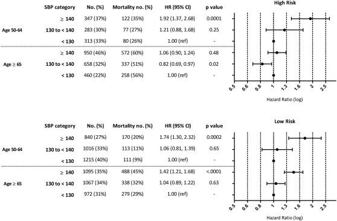

Fig. 1. Association between achieved [systolic blood pressure](https://www.sciencedirect.com/topics/medicine-and-dentistry/systolic-blood-pressure) and long-term mortality rates, stratifying by age and risk group. CI, confidence interval; HR, adjusted hazard ratio; No., number; SBP, systolic blood pressure.

## 4. Discussion

Our data indicate that, among older hypertensive women at high-risk due to prior coronary events, achieving in-trial mean SBP 130–139 mmHg is associated with decreased long-term, all-cause mortality when compared with SBP<130 mmHg. When examining the association between achieving SBP 130–139 mmHg with age individually, we observed the mortality hazard favored decreased mortality in older women (HR 0.94, 95% CI 0.84–1.05, p = 0.27), albeit not statistically significant. By analyzing women aged ≥65 with prior coronary events, we have selected an endotype at very high risk of death, in which decrease of SBP to <130 mmHg was not associated with improved outcomes. Thus our results support recommendations of ESC/ESH Hypertension guidelines [7] to target SBP of 130–139 in patients ≥65 years old with hypertension and CAD, specifically in women with prior coronary events.

The link between SBP and all-cause mortality in CAD has been previously investigated in studies enrolling mainly men and with shorter-term follow-up. The CLARIFY registry investigators observed that in 22,672 stable CAD patients (75% men) with hypertension, SBP between 130–139 mmHg was associated with similar rates of all-cause death as SBP between 120-129 mmHg (HR 0.98, 95% CI 0.87–1.11, p = 0.7701) after median 5 years of follow-up [3]. The PROVE-IT TIMI 22 trial also suggests a slightly higher SBP is associated with survival benefit in patients with recent [acute coronary syndrome](https://www.sciencedirect.com/topics/medicine-and-dentistry/acute-coronary-syndrome) [9]. In 4162 patients (78% men) enrolled within 10 days after an acute coronary syndrome, average SBP of 130–140 mmHg was associated with the lowest risk of death during an average follow-up of 24 months [9]. Our data extend these prior findings to a large cohort of older women with chronic CAD, and support the suggestion that achieved in-trial SBP continues to predict long-term mortality well over a decade into the future.

Mechanisms underlying the association between lower SBP and higher all-cause mortality in this endotype have not been completely elucidated. SBP lowering <140 mmHg may be associated with higher rates of renal failure [10,11]. [Orthostatic hypotension](https://www.sciencedirect.com/topics/medicine-and-dentistry/orthostatic-hypotension), which is more frequent in women [14], may also contribute to worse outcomes. However, contemporary studies conducted in mainly male populations failed to support an association between lower BP targets and a higher incidence of orthostatic hypotension [12,13]. Reverse-causality, wherein patients with lower achieved SBP also have greater baseline cardiovascular risk, is less likely to have contributed to our findings, as we adjusted for baseline markers of more severe disease, including heart failure, prior stroke or [TIA](https://www.sciencedirect.com/topics/medicine-and-dentistry/transient-ischemic-attack), diabetes, and CKD.

### 4.1. Limitations

The greatest strength of our study is that it included the largest cohort of women with hypertension and chronic CAD enrolled in a clinical trial to date; moreover women had high comorbidity burden, which is representative of the general population of older women with cardiovascular disease. It also had one of the longest follow-up periods for women, and intent to examine outcomes by sex and older age was prespecified. The major limitation is that after trial termination, data were not captured on medications, BP, or non-fatal clinical evolution. However, it is likely that [INVEST](https://www.sciencedirect.com/topics/medicine-and-dentistry/verapamil) women continued on a similar [antihypertensive therapy](https://www.sciencedirect.com/topics/medicine-and-dentistry/antihypertensive-therapy) after the trial, as site investigators were primary-care physicians and they were informed that BP control was the best reported at that time (~72%) and outcomes between the tested [antihypertensive](https://www.sciencedirect.com/topics/medicine-and-dentistry/antihypertensive-agent) strategies were equivalent; furthermore the sponsor offered participants free drugs for at least 3 additional months after trial termination. Other limitations include the post-hoc nature of the analysis, the fact that SBP <130 was not a prespecified target for all INVEST patients, but only for those with diabetes or CKD, and that no adjustment was made for multiple testing.

## 5. Conclusion

In women with CAD and prior coronary events aged ≥65 years, achieving mean in-trial SBP of 130–139 mmHg during INVEST was associated with decreased long-term, all-cause mortality when compared with achieving SBP <130 mmHg.

## Funding

INVEST was funded by grants from BASF Pharma, Abbott, and the Univ. of Florida (UF) Research Foundation and Opportunity Fund.

## Declaration of Competing Interest

The authors declare no conflicts of interest.

## References

**[1]**

S.S. Virani, A. Alonso, E.J. Benjamin, M.S. Bittencourt, C.W. Callaway, A.P. Carson, A.M. Chamberlain, A.R. Chang, S. Cheng, F.N. Delling, L. Djousse, M.S.V. Elkind, J.F. Ferguson, M. Fornage, S.S. Khan, B.M. Kissela, K.L. Knutson, T.W. Kwan, D.T. Lackland, T.T. Lewis, J.H. Lichtman, C.T. Longenecker, M.S. Loop, P.L. Lutsey, S.S. Martin, K. Matsushita, A.E. Moran, M.E. Mussolino, A.M. Perak, W.D. Rosamond, G.A. Roth, U.K.A. Sampson, G.M. Satou, E.B. Schroeder, S.H. Shah, C.M. Shay, N.L. Spartano, A. Stokes, D.L. Tirschwell, L.B. VanWagner, C.W. Tsao, American Heart Association Council on Epidemiology and Prevention Statistics Committee and Stroke Statistics Subcommittee

**Heart disease and stroke statistics-2020 update: a report from the American heart association**

Circulation, 141 (2020), pp. e139-e596

[View Record in Scopus](https://www.scopus.com/inward/record.url?eid=2-s2.0-85131172161&partnerID=10&rel=R3.0.0)Google Scholar

**[2]**

P.K. Whelton, R.M. Carey, W.S. Aronow, D.E. Casey Jr., K.J. Collins, C. Dennison Himmelfarb, S.M. DePalma, S. Gidding, K.A. Jamerson, D.W. Jones, E.J. MacLaughlin, P. Muntner, B. Ovbiagele, S.C. Smith Jr., C.C. Spencer, R.S. Stafford, S.J. Taler, R.J. Thomas, K.A. Williams, J.D. Williamson Sr., J.T. Wright Jr.

**2017 ACC/AHA/AAPA/ABC/ACPM/AGS/APhA/ASH/ASPC/NMA/PCNA guideline for the prevention, detection, evaluation, and management of high blood pressure in adults: executive summary: a report of the American College of Cardiology/American heart association task force on clinical practice guidelines**

Hypertension, 71 (2018), pp. 1269-1324

[CrossRef](https://doi.org/10.1161/hyp.0000000000000066)[View Record in Scopus](https://www.scopus.com/inward/record.url?eid=2-s2.0-85054193365&partnerID=10&rel=R3.0.0)Google Scholar

**[3]**

E. Vidal-Petiot, I. Ford, N. Greenlaw, R. Ferrari, K.M. Fox, J.C. Tardif, M. Tendera, L. Tavazzi, D.L. Bhatt, P.G. Steg, CLARIFY Investigators

**Cardiovascular event rates and mortality according to achieved systolic and diastolic blood pressure in patients with stable coronary artery disease: an international cohort study**

Lancet, 388 (2016), pp. 2142-2152

[Article](https://www.sciencedirect.com/science/article/pii/S0140673616313265)[Download PDF](https://www.sciencedirect.com/science/article/pii/S0140673616313265/pdfft?md5=57840fac59092078df0d97f97f28b414&pid=1-s2.0-S0140673616313265-main.pdf)[View Record in Scopus](https://www.scopus.com/inward/record.url?eid=2-s2.0-84994171988&partnerID=10&rel=R3.0.0)Google Scholar

**[4]**

F.H. Messerli, G. Mancia, C.R. Conti, A.C. Hewkin, S. Kupfer, A. Champion, R. Kolloch, A. Benetos, C.J. Pepine

**Dogma disputed: can aggressively lowering blood pressure in hypertensive patients with coronary artery disease be dangerous?**

Ann. Intern. Med., 144 (2006), pp. 884-893

[CrossRef](https://doi.org/10.7326/0003-4819-144-12-200606200-00005)[View Record in Scopus](https://www.scopus.com/inward/record.url?eid=2-s2.0-33745295923&partnerID=10&rel=R3.0.0)[Google Scholar](https://scholar.google.com/scholar?q=Dogma%20disputed:%20can%20aggressively%20lowering%20blood%20pressure%20in%20hypertensive%20patients%20with%20coronary%20artery%20disease%20be%20dangerous)

**[5]**

N.K. Wenger, K.C. Ferdinand, C.N. Bairey Merz, M.N. Walsh, M. Gulati, C.J. Pepine, American College of Cardiology Cardiovascular Disease in Women Committee

**Women, hypertension, and the systolic blood pressure intervention trial**

Am. J. Med., 129 (2016), pp. 1030-1036

[Article](https://www.sciencedirect.com/science/article/pii/S0002934316306908)[Download PDF](https://www.sciencedirect.com/science/article/pii/S0002934316306908/pdfft?md5=e0ecc3752d57571a43b05535ab5c9fc8&pid=1-s2.0-S0002934316306908-main.pdf)[View Record in Scopus](https://www.scopus.com/inward/record.url?eid=2-s2.0-84990055098&partnerID=10&rel=R3.0.0)Google Scholar

**[6]**

S.R. Garrison, M.R. Kolber, C.S. Korownyk, R.K. McCracken, B.S. Heran, G.M. Allan

**Blood pressure targets for hypertension in older adults**

Cochrane Database Syst. Rev., 8 (2017), p. CD011575

[View Record in Scopus](https://www.scopus.com/inward/record.url?eid=2-s2.0-85027158879&partnerID=10&rel=R3.0.0)Google Scholar

**[7]**

B. Williams, G. Mancia, W. Spiering, E. Agabiti Rosei, M. Azizi, M. Burnier, D.L. Clement, A. Coca, G. de Simone, A. Dominiczak, T. Kahan, F. Mahfoud, J. Redon, L. Ruilope, A. Zanchetti, M. Kerins, S.E. Kjeldsen, R. Kreutz, S. Laurent, G.Y.H. Lip, R. McManus, K. Narkiewicz, F. Ruschitzka, R.E. Schmieder, E. Shlyakhto, C. Tsioufis, V. Aboyans, I. Desormais, ESC Scientific Document Group

**2018 ESC/ESH Guidelines for the management of arterial hypertension**

Eur. Heart J., 39 (2018), pp. 3021-3104

[CrossRef](https://doi.org/10.1093/eurheartj/ehy339)[Google Scholar](https://scholar.google.com/scholar?q=2018%20ESCESH%20Guidelines%20for%20the%20management%20of%20arterial%20hypertension)

**[8]**

C.J. Pepine, E.M. Handberg, R.M. Cooper-DeHoff, R.G. Marks, P. Kowey, F.H. Messerli, G. Mancia, J.L. Cangiano, D. Garcia-Barreto, M. Keltai, S. Erdine, H.A. Bristol, H.R. Kolb, G.L. Bakris, J.D. Cohen, W.W. Parmley, INVEST Investigators

**A calcium antagonist vs a non-calcium antagonist hypertension treatment strategy for patients with coronary artery disease. The International Verapamil-Trandolapril Study (INVEST): a randomized controlled trial**

JAMA, 290 (2003), pp. 2805-2816

[View Record in Scopus](https://www.scopus.com/inward/record.url?eid=2-s2.0-0345492460&partnerID=10&rel=R3.0.0)Google Scholar

**[9]**

S. Bangalore, J. Qin, S. Sloan, S.A. Murphy, C.P. Cannon, PROVE IT-TIMI 22 Trial Investigators

**What is the optimal blood pressure in patients after acute coronary syndromes?: relationship of blood pressure and cardiovascular events in the PRavastatin OR atorVastatin Evaluation and Infection Therapy-Thrombolysis in Myocardial Infarction (PROVE IT-TIMI) 22 trial**

Circulation, 122 (2010), pp. 2142-2151

[View Record in Scopus](https://www.scopus.com/inward/record.url?eid=2-s2.0-78650170501&partnerID=10&rel=R3.0.0)Google Scholar

**[10]**

C. Bavishi, S. Bangalore, F.H. Messerli

**Outcomes of intensive blood pressure lowering in older hypertensive patients**

J. Am. Coll. Cardiol., 69 (2017), pp. 486-493

[Article](https://www.sciencedirect.com/science/article/pii/S0735109716372151)[Download PDF](https://www.sciencedirect.com/science/article/pii/S0735109716372151/pdfft?md5=c18f229fe99db5613dfdb4879d92d75c&pid=1-s2.0-S0735109716372151-main.pdf)[View Record in Scopus](https://www.scopus.com/inward/record.url?eid=2-s2.0-85011659537&partnerID=10&rel=R3.0.0)Google Scholar

**[11]**

M.V. Rocco, K.M. Sink, L.C. Lovato, D.F. Wolfgram, T.B. Wiegmann, B.M. Wall, K. Umanath, F. Rahbari-Oskoui, A.C. Porter, R. Pisoni, C.E. Lewis, J.B. Lewis, J.P. Lash, L.A. Katz, A.T. Hawfield, W.E. Haley, B.I. Freedman, J.P. Dwyer, P.E. Drawz, M. Dobre, A.K. Cheung, R.C. Campbell, U. Bhatt, S. Beddhu, P.L. Kimmel, D.M. Reboussin, G.M. Chertow, SPRINT Research Group

**Effects of intensive blood pressure treatment on acute kidney injury events in the Systolic Blood Pressure Intervention Trial (SPRINT)**

Am. J. Kidney Dis., 71 (2018), pp. 352-361

[Article](https://www.sciencedirect.com/science/article/pii/S0272638617309629)[Download PDF](https://www.sciencedirect.com/science/article/pii/S0272638617309629/pdfft?md5=4c987435508ace2bd63fbcd11f9fdac8&pid=1-s2.0-S0272638617309629-main.pdf)[View Record in Scopus](https://www.scopus.com/inward/record.url?eid=2-s2.0-85034780816&partnerID=10&rel=R3.0.0)[Google Scholar](https://scholar.google.com/scholar?q=Effects%20of%20intensive%20blood%20pressure%20treatment%20on%20acute%20kidney%20injury%20events%20in%20the%20Systolic%20Blood%20Pressure%20Intervention%20Trial)

**[12]**

S.P. Juraschek, A.A. Taylor, J.T. Wright, G.W. Evans, E.R. Miller, T.B. Plante, W.C. Cushman, T.R. Gure, W.E. Haley, I. Moinuddin, J. Nord, S. Oparil, C. Pedley, C.L. Roumie, J. Whittle, A. Wiggers, C. Finucane, R. Anne Kenny, L.J. Appel, R.R. Townsend, SPRINT Research Group

**Orthostatic hypotension, cardiovascular outcomes, and adverse events: results from SPRINT**

Hypertension, 75 (2020), pp. 660-667

[CrossRef](https://doi.org/10.1161/hypertensionaha.119.14309)[View Record in Scopus](https://www.scopus.com/inward/record.url?eid=2-s2.0-85081143112&partnerID=10&rel=R3.0.0)Google Scholar

**[13]**

J.L. Fleg, G.W. Evans, K.L. Margolis, J. Barzilay, J.N. Basile, J.T. Bigger, J.A. Cutler, R. Grimm, C. Pedley, K. Peterson, R. Pop-Busui, J. Sperl-Hillen, W.C. Cushman

**Orthostatic hypotension in the ACCORD (action to control cardiovascular risk in diabetes) blood pressure trial: prevalence, incidence, and prognostic significance**

Hypertension, 68 (2016), pp. 888-895

[View Record in Scopus](https://www.scopus.com/inward/record.url?eid=2-s2.0-84981249263&partnerID=10&rel=R3.0.0)[Google Scholar](https://scholar.google.com/scholar?q=Orthostatic%20hypotension%20in%20the%20ACCORD%20%20blood%20pressure%20trial:%20prevalence,%20incidence,%20and%20prognostic%20significance)

**[14]**

Y.C. Cheng, A. Vyas, E. Hymen, L.C. Perlmuter

**Gender differences in orthostatic hypotension**

Am. J. Med. Sci., 342 (3) (2011), pp. 221-225

[Article](https://www.sciencedirect.com/science/article/pii/S0002962915311848)[Download PDF](https://www.sciencedirect.com/science/article/pii/S0002962915311848/pdfft?md5=56b73dd67bcd453b19381f55037143a7&pid=1-s2.0-S0002962915311848-main.pdf)[CrossRef](https://doi.org/10.1097/MAJ.0b013e318208752b)[View Record in Scopus](https://www.scopus.com/inward/record.url?eid=2-s2.0-80052262939&partnerID=10&rel=R3.0.0)[Google Scholar](https://scholar.google.com/scholar_lookup?title=Gender%20differences%20in%20orthostatic%20hypotension&publication_year=2011&author=Y.C.%20Cheng&author=A.%20Vyas&author=E.%20Hymen&author=L.C.%20Perlmuter)

- 2020, International Journal of Cardiology: Hypertension

- 2021, Acta Medica Mediterranea

**<sup>☆</sup>**

All authors take responsibility for all aspects of the reliability and freedom from bias of the data presented and their discussed interpretation.

© 2020 The Authors. Published by Elsevier B.V.

Citations

- Citation Indexes: 2

Captures

- Readers: 8

Social Media